# Wind Resource Characterization

MECE 4210 Energy Infrastructure Planning

To determine wind power productivity and wind resource characterization, wind speed measurements over long periods (months and/or years) are usually used and most of the time required. The wind power production is dependent not only on wind speed but also on wind turbine efficiency and wind farm geometry arrangement. We will learn later that curtailment is also important in the power production equation. To simplify this assignment we will analyze the power of only one wind turbine.

The following datasets are available:  
* Three years (2012, 2013 and 2014) of wind speed measurements from [Lawrence Livermore National Laboratory](http://www-metdat.llnl.gov/cgi-pub/index.pl) at 52m height at full resolution or 15 minute sampling time.  
* Two power curves for a representative IEC 61400 Class 2 and Class 3 wind turbine with 90m diameter and 1.5MW power rating. These curves, among others, are available in the [System Advisory Model (SAM)](https://sam.nrel.gov/download) software from NREL.

**Question 1** Estimate wind speed values at a 70m height, which is a potential hub height for a 90m diameter wind turbine. The logarithmic profile of wind speed can be used in this question, using $z_0$=100mm for a few trees surface: $\frac{U(z)}{U(z_r)} = \frac{\ln(z/z_0)}{\ln(z_r/z_0)}$ Where $U(z)$ is the estimated speed at a potential hub height $z$ and $U(z_r)$ is the reference wind speed at height $z_r$. Calculate hourly averages wind speed measurements for this data. Plot the hourly wind speed average for 2012.

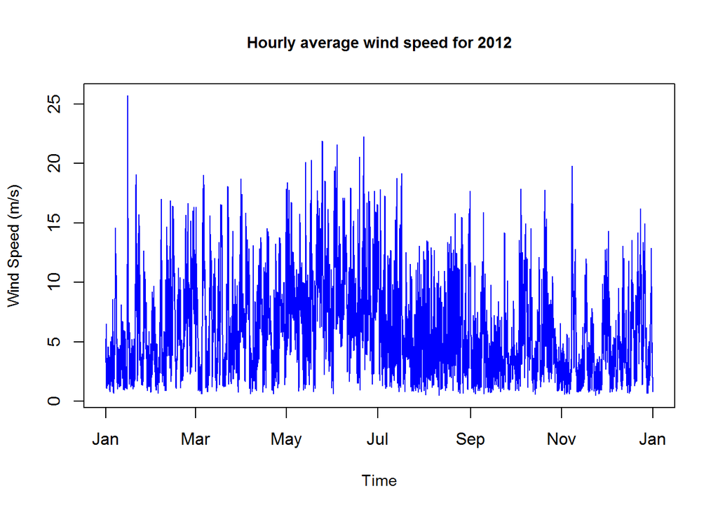

**Question 2**  
Plot a histogram of the 2012 data using 0.5m/s bins for a quick way to look at the distribution of the data. Using the analytical/empirical method (Justus, 1978), find the shape $k$ and scale $c$ factors for a weibull probability density function (pdf) of this data and plot the weibull distribution. $k = \left(\frac{\sigma_U}{\overline{U}}\right)^{-1.086}$ $c=\frac{\overline{U}}{\Gamma (1+1/k)}$ Where $\sigma_U$ is the standard deviation of the wind speed, $\overline{U}$ is the mean wind speed and $\Gamma$ is the gamma function.

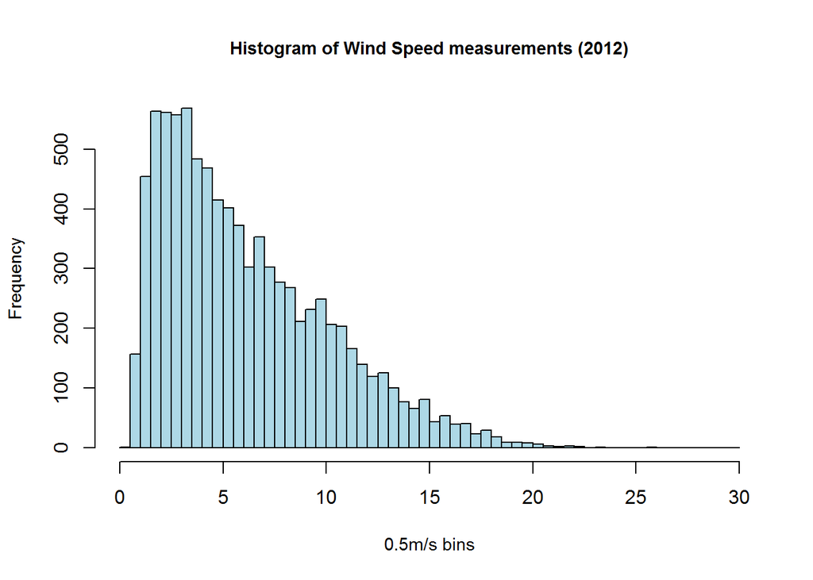

|  | Shape | Scale |
| --- | --- | --- |
| Parameter | 1.58192 | 6.850448 |

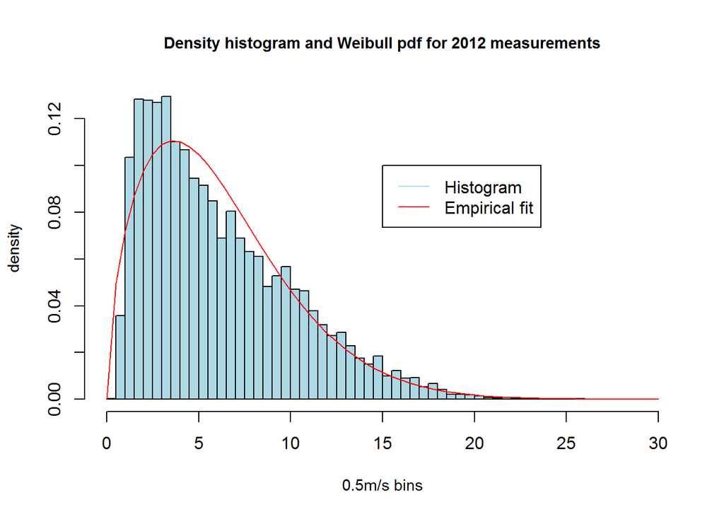

```r
R commands helpful for this assignments are:
hist(x, breaks = seq(0,15,by = 0.5))
dweibull(seq(0,15,by=0.5), Wind.shape, Wind.scale)
fitdistr(x,"weibull")
```

**Question 3**  
Use the fitdistr function in R (or fitdist in MATLAB) to find the best Weibull pdf for this data. Compare this new pdf with the pdf found in **Question 2**.

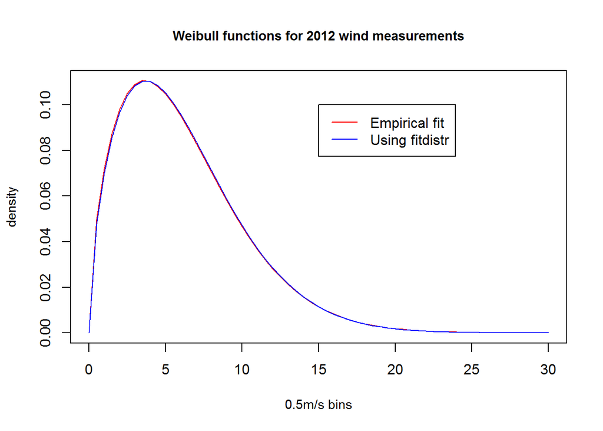

|  | Shape | Scale |
| --- | --- | --- |
| Empirical values | 1.581920 | 6.850448 |
| Fitdistr | 1.597725 | 6.885956 |

**Question 4** Find the wind duration curve for the wind speed data in 2012. The steps to calculate this curve are:  
* Arrange the wind speed data in bins as done in **Question 2**.  
* Find the number of hours that a given wind velocity is exceeded.  
* Plot the resulting curve.

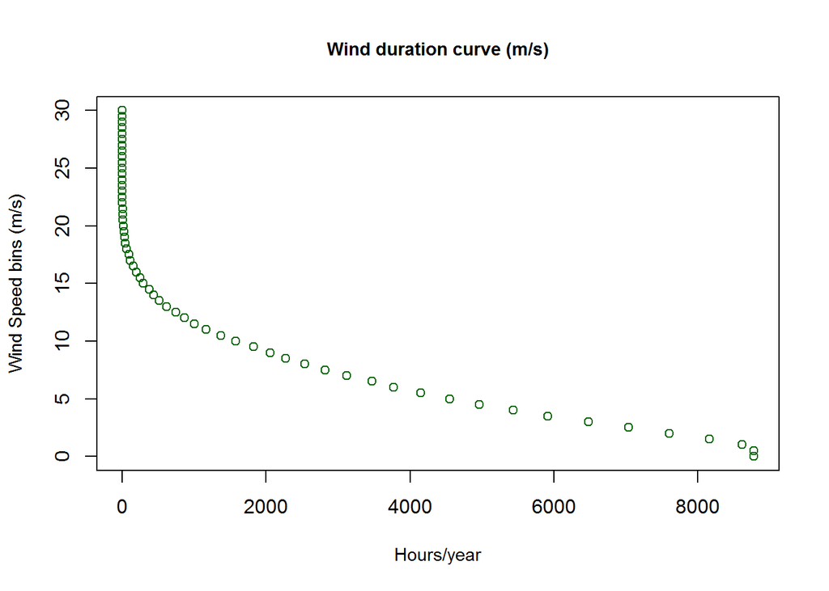

**Question 5**  
Find the yearly average wind power density per unit area using the hourly average data calculated in **Question 1** and direct use of data. $\frac{\overline{P}}{A} = \frac{\overline{P}}{\pi r^2} = \frac{1}{2} \rho \frac{1}{N} \sum \limits_{i=1}^N U_i^3$ Where $\rho$ = 1.225 kg/m<sup>3</sup> is the air density under standard conditions. Tabulate the $P/A$ value for each year, then multiply this by the sweep area of a 90m diameter wind turbine to calculate the “ideal” power available in this area.

|  | P/A using hourly averages (W/m2) | P/A Using 15 min data (W/m2) |
| --- | --- | --- |
| 2012 | 362.3932 | 322.4207 |
| 2013 | 393.2294 | 348.1956 |
| 2014 | 346.8704 | 308.1603 |

[output not shown]

NOTE: The values using the 15min data are for reference and were not requested in the assignment

**Question 6**  
In two paraghraphs describe the purpose of IEC 61400 and describe the difference between Class 2 and Class 3 power turbines. Plot both provided power curves using wind speed in the x-axis.

```r
#A Wind Class 3 turbine is designed for an easy life with average wind speeds up to 7.5 m/s
#Class 3 turbines typically have extra-large rotors to allow them to capture as much energy as possible from the lower wind speeds
#Wind Class 2 turbines are for windier sites up to 8.5 m/s average, and are the most common class of wind turbines available.
```

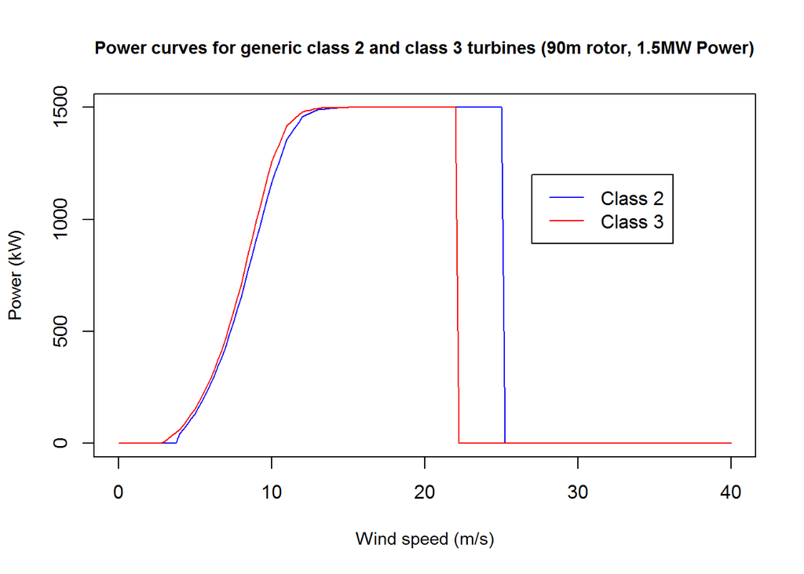

Using the formula below, calculate $C_p \eta$ values for each power curve as functions of the wind speed, where $C_p$ is the rotor power coefficient, and $\eta$ is the drivetrain efficiency.

$P_w(U) = \frac{1}{2} \rho A C_p \eta U^3$

Plot these $C_p \eta$ values and compare their maxima.

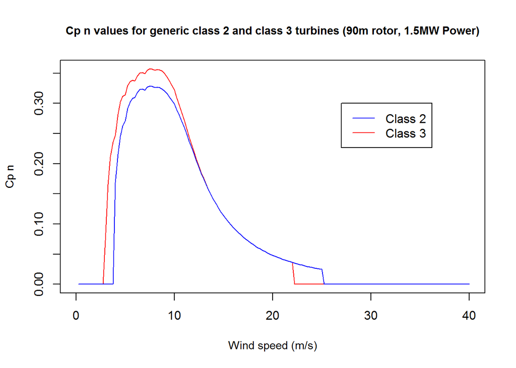

[output not shown]

**Question 7** Variability of the wind regime and the characteristics of the wind machine will greatly change the output of an actual machine operating in a real wind regime. Calculate the yearly power and energy output of this turbine using both power curves Class 3 with two methods:

1. Direct Use of wind speed measurement data:

$\overline{P_w} = \frac{1}{N} \sum \limits_{i=1}^N P_w (U_i)$

|  | Power C2 (kW) | Power C3 (kW) | Energy C2 (MWh) | Energy C3 (MWh) |
| --- | --- | --- | --- | --- |
| 2012 | 440.9253 | 467.5946 | 3869.560 | 4103.610 |
| 2013 | 461.8086 | 487.3258 | 4041.287 | 4264.588 |
| 2014 | 411.7349 | 436.6851 | 3596.092 | 3814.008 |

2. Using a Weibull distribution parameters found in **Question 3**:

$\overline{P_w} = \sum \limits_{j=1}^{N_B} \left( e^{-(\frac{U_{j-1}}{c}) ^k} - e^{-(\frac{U_j}{c}) ^k} \right) P_w (\frac{U_{j-1}+U_j}{2})$

The second method is valuable if no long term measurement is available, but the probability distribution of wind speed is known.

|  | Power C2 (kW) | Power C3 (kW) | Energy C2 (MWh) | Energy C3 (MWh) |
| --- | --- | --- | --- | --- |
| 2012 | 437.0268 | 463.5275 | 3828.355 | 4060.501 |
| 2013 | 444.8424 | 469.1068 | 3896.820 | 4109.376 |
| 2014 | 415.8429 | 441.7153 | 3642.784 | 3869.426 |